# Practical Machine Learning Course Project

## Model Fitting

The next step is to fit models to see how accurately we can predict the ‘classe’ variable with the remaining variables.

#### Linear Discriminant Analysis

```r
modLDA <- train(data = training,
                classe ~ .,
                method = "lda")
```

```r
predLDA <- predict(modLDA, newdata = testing)
confusionMatrix(testing$classe, predLDA)
```

```
## Confusion Matrix and Statistics
##
##           Reference
## Prediction    A    B    C    D    E
##          A 1134   32  116  110    3
##          B  157  605  104   40   43
##          C   91   89  548  101   26
##          D   43   38   82  614   27
##          E   43  145   72   92  549
##
## Overall Statistics
##
##                Accuracy : 0.7035
##                  95% CI : (0.6905, 0.7163)
##     No Information Rate : 0.2993
##     P-Value [Acc > NIR] : < 2.2e-16
##
##                   Kappa : 0.6247
##  Mcnemar's Test P-Value : < 2.2e-16
##
## Statistics by Class:
##
##                      Class: A Class: B Class: C Class: D Class: E
## Sensitivity            0.7725   0.6656   0.5944   0.6416   0.8472
## Specificity            0.9240   0.9139   0.9229   0.9519   0.9173
## Pos Pred Value         0.8129   0.6375   0.6409   0.7637   0.6093
## Neg Pred Value         0.9048   0.9231   0.9076   0.9163   0.9753
## Prevalence             0.2993   0.1854   0.1880   0.1951   0.1321
## Detection Rate         0.2312   0.1234   0.1117   0.1252   0.1119
## Detection Prevalence   0.2845   0.1935   0.1743   0.1639   0.1837
## Balanced Accuracy      0.8483   0.7897   0.7586   0.7967   0.8823
```

#### Classification Tree

```r
modCT<-train(data = training,
             classe ~ .,
             method = "rpart")
```

```r
modCT$finalModel
```

```
## n= 14718
##
## node), split, n, loss, yval, (yprob)
##       * denotes terminal node
##
##  1) root 14718 10533 A (0.28 0.19 0.17 0.16 0.18)
##    2) roll_belt< 129.5 13382  9251 A (0.31 0.21 0.19 0.18 0.11)
##      4) pitch_forearm< -33.95 1200     8 A (0.99 0.0067 0 0 0) *
##      5) pitch_forearm>=-33.95 12182  9243 A (0.24 0.23 0.21 0.2 0.12)
##       10) yaw_belt>=169.5 597    57 A (0.9 0.045 0 0.047 0.0034) *
##       11) yaw_belt< 169.5 11585  8772 B (0.21 0.24 0.22 0.21 0.12)
##         22) magnet_dumbbell_z< -93.5 1418   587 A (0.59 0.29 0.051 0.056 0.021) *
##         23) magnet_dumbbell_z>=-93.5 10167  7672 C (0.15 0.24 0.25 0.23 0.14)
##           46) pitch_belt< -42.95 616    91 B (0.016 0.85 0.084 0.021 0.026) *
##           47) pitch_belt>=-42.95 9551  7108 C (0.16 0.2 0.26 0.24 0.14)
##             94) accel_forearm_x>=-100.5 5858  4281 C (0.21 0.23 0.27 0.12 0.18) *
##             95) accel_forearm_x< -100.5 3693  2105 D (0.09 0.15 0.23 0.43 0.093) *
##    3) roll_belt>=129.5 1336    54 E (0.04 0 0 0 0.96) *
```

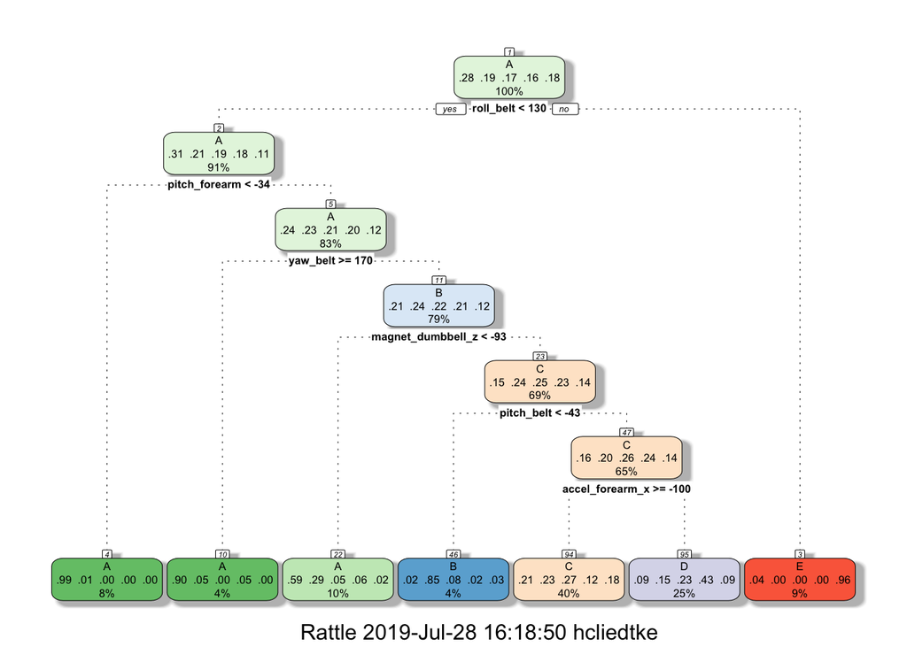

```r
fancyRpartPlot(modCT$finalModel)
```

```r
predCT<-predict(modCT, newdata = testing)
confusionMatrix(predCT, testing$classe)
```

```
## Confusion Matrix and Statistics
##
##           Reference
## Prediction   A   B   C   D   E
##          A 860 149  32  41  10
##          B   1 164  20   4   2
##          C 400 446 515 229 357
##          D 120 190 288 530 109
##          E  14   0   0   0 423
##
## Overall Statistics
##
##                Accuracy : 0.5082
##                  95% CI : (0.4941, 0.5222)
##     No Information Rate : 0.2845
##     P-Value [Acc > NIR] : < 2.2e-16
##
##                   Kappa : 0.3869
##  Mcnemar's Test P-Value : < 2.2e-16
##
## Statistics by Class:
##
##                      Class: A Class: B Class: C Class: D Class: E
## Sensitivity            0.6165  0.17281   0.6023   0.6592  0.46948
## Specificity            0.9339  0.99317   0.6463   0.8276  0.99650
## Pos Pred Value         0.7875  0.85864   0.2645   0.4285  0.96796
## Neg Pred Value         0.8597  0.83344   0.8850   0.9253  0.89299
## Prevalence             0.2845  0.19352   0.1743   0.1639  0.18373
## Detection Rate         0.1754  0.03344   0.1050   0.1081  0.08626
## Detection Prevalence   0.2227  0.03895   0.3970   0.2522  0.08911
## Balanced Accuracy      0.7752  0.58299   0.6243   0.7434  0.73299
```

#### Boosting

```r
modBOOST<-train(data = training,
                classe ~ .,
                method = "gbm",
                verbose=F)
```

```r
print(modBOOST)
```

```
## Stochastic Gradient Boosting
##
## 14718 samples
##    52 predictor
##     5 classes: 'A', 'B', 'C', 'D', 'E'
##
## No pre-processing
## Resampling: Bootstrapped (25 reps)
## Summary of sample sizes: 14718, 14718, 14718, 14718, 14718, 14718, ...
## Resampling results across tuning parameters:
##
##   interaction.depth  n.trees  Accuracy   Kappa
##   1                   50      0.7484804  0.6812009
##   1                  100      0.8167595  0.7681216
##   1                  150      0.8515282  0.8121473
##   2                   50      0.8530557  0.8138871
##   2                  100      0.9041961  0.8787919
##   2                  150      0.9287382  0.9098508
##   3                   50      0.8963901  0.8688642
##   3                  100      0.9401301  0.9242672
##   3                  150      0.9583238  0.9472851
##
## Tuning parameter 'shrinkage' was held constant at a value of 0.1
##
## Tuning parameter 'n.minobsinnode' was held constant at a value of 10
## Accuracy was used to select the optimal model using the largest value.
## The final values used for the model were n.trees = 150,
##  interaction.depth = 3, shrinkage = 0.1 and n.minobsinnode = 10.
```

```r
predBOOST<-predict(modBOOST, newdata = testing)
confusionMatrix(predBOOST, testing$classe)
```

```
## Confusion Matrix and Statistics
##
##           Reference
## Prediction    A    B    C    D    E
##          A 1386   20    0    1    2
##          B    7  904   25    3    6
##          C    1   24  815   20    5
##          D    1    1   13  775   11
##          E    0    0    2    5  877
##
## Overall Statistics
##
##                Accuracy : 0.97
##                  95% CI : (0.9649, 0.9746)
##     No Information Rate : 0.2845
##     P-Value [Acc > NIR] : < 2e-16
##
##                   Kappa : 0.9621
##  Mcnemar's Test P-Value : 0.01909
##
## Statistics by Class:
##
##                      Class: A Class: B Class: C Class: D Class: E
## Sensitivity            0.9935   0.9526   0.9532   0.9639   0.9734
## Specificity            0.9934   0.9896   0.9877   0.9937   0.9983
## Pos Pred Value         0.9837   0.9566   0.9422   0.9675   0.9921
## Neg Pred Value         0.9974   0.9886   0.9901   0.9929   0.9940
## Prevalence             0.2845   0.1935   0.1743   0.1639   0.1837
## Detection Rate         0.2826   0.1843   0.1662   0.1580   0.1788
## Detection Prevalence   0.2873   0.1927   0.1764   0.1633   0.1803
## Balanced Accuracy      0.9935   0.9711   0.9704   0.9788   0.9858
```

#### Random Forest

```r
modRF<-train(data=training,
              classe~.,
              method="rf",
              prox=T)
```

```r
predRF<-predict(modRF, newdata = testing)
confusionMatrix(predRF, testing$classe)
```

```
## Confusion Matrix and Statistics
##
##           Reference
## Prediction    A    B    C    D    E
##          A 1394    0    0    0    0
##          B    1  949    0    0    1
##          C    0    0  855    2    0
##          D    0    0    0  801    0
##          E    0    0    0    1  900
##
## Overall Statistics
##
##                Accuracy : 0.999
##                  95% CI : (0.9976, 0.9997)
##     No Information Rate : 0.2845
##     P-Value [Acc > NIR] : < 2.2e-16
##
##                   Kappa : 0.9987
##  Mcnemar's Test P-Value : NA
##
## Statistics by Class:
##
##                      Class: A Class: B Class: C Class: D Class: E
## Sensitivity            0.9993   1.0000   1.0000   0.9963   0.9989
## Specificity            1.0000   0.9995   0.9995   1.0000   0.9998
## Pos Pred Value         1.0000   0.9979   0.9977   1.0000   0.9989
## Neg Pred Value         0.9997   1.0000   1.0000   0.9993   0.9998
## Prevalence             0.2845   0.1935   0.1743   0.1639   0.1837
## Detection Rate         0.2843   0.1935   0.1743   0.1633   0.1835
## Detection Prevalence   0.2843   0.1939   0.1748   0.1633   0.1837
## Balanced Accuracy      0.9996   0.9997   0.9998   0.9981   0.9993
```

#### Compare model accuracies

Based on the model accuracies, we can choose which model performed best

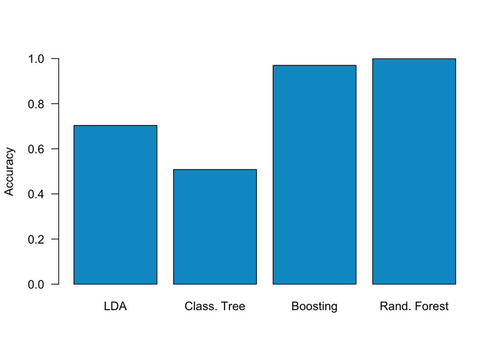

```r
lda.acc<-confusionMatrix(predLDA, testing$classe)$overall["Accuracy"]
CT.acc<-confusionMatrix(predCT, testing$classe)$overall["Accuracy"]
boost.acc<-confusionMatrix(predBOOST, testing$classe)$overall["Accuracy"]
RF.acc<-confusionMatrix(predRF, testing$classe)$overall["Accuracy"]

barplot(c(lda.acc, CT.acc, boost.acc, RF.acc),
        col="deepskyblue3",
        names.arg = c("LDA","Class. Tree","Boosting","Rand. Forest"),
        ylim=c(0,1),
        ylab="Accuracy", las=1)
```

Random Forest is the best model, slightly outperforming boosting. One could combine predictors to impove the model, but as the accuracy is pretty good it is probably not necessary here.

## Applying the final model

Having determined which model to use, we can now apply this model to the real data (the testing data provided by the website) to predict whether each user was performing the exercise correctly or not.

```r
predPML.testing<-predict(modRF, newdata=pml.testing)
print(data.frame(user_name=pml.testing$user_name, problem_id=pml.testing$problem_id, predicted_class=(predPML.testing)))
```

```
##    user_name problem_id predicted_class
## 1      pedro          1               B
## 2     jeremy          2               A
## 3     jeremy          3               B
## 4     adelmo          4               A
## 5     eurico          5               A
## 6     jeremy          6               E
## 7     jeremy          7               D
## 8     jeremy          8               B
## 9   carlitos          9               A
## 10   charles         10               A
## 11  carlitos         11               B
## 12    jeremy         12               C
## 13    eurico         13               B
## 14    jeremy         14               A
## 15    jeremy         15               E
## 16    eurico         16               E
## 17     pedro         17               A
## 18  carlitos         18               B
## 19     pedro         19               B
## 20    eurico         20               B
```